## Loading and preprocessing the data

The first step is to download the data, extract the zip file, and prepare the data set

```r
library(sqldf)
```

```r
download.file("Activity_Data.zip",
              url = "https://d396qusza40orc.cloudfront.net/repdata%2Fdata%2Factivity.zip")

unzip(zipfile = "Activity_Data.zip")
activity <- read.csv("activity.csv")
activity$date <- as.POSIXct(activity$date, format = '%Y-%m-%d')
activity <- data.frame(date = activity$date, weekday = weekdays(activity$date),
                       steps = activity$steps, interval = activity$interval)
```

## What is mean total number of steps taken per day?

1. The prepared data set is then taken to aggregate the total number of steps by date

```r
daily_activity <- aggregate(activity$steps, by = list(activity$date), FUN = sum,
                            na.rm = TRUE)

names(daily_activity) <- c("Date", "Agg_activity")
```

2. The aggregated data is then used to create a plot

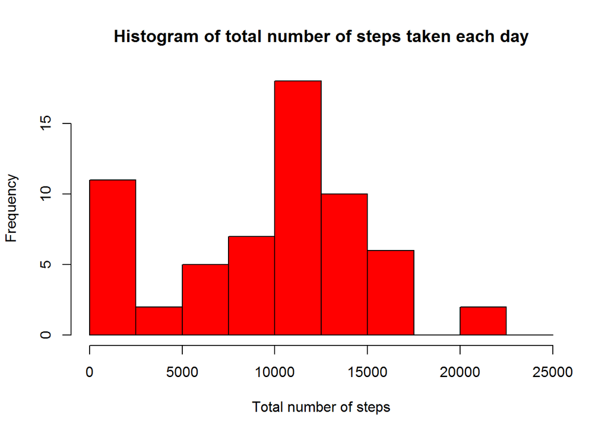

```r
hist(daily_activity$Agg_activity, xlab = "Total number of steps",
     main = "Histogram of total number of steps taken each day", col = "red",
     breaks = seq(from = 0, to = 25000, by = 2500))
```

3. The mean and median are computed using the R code below; mean is 9354 and 10395

```r
mean(daily_activity$Agg_activity)
```

```
## [1] 9354.23
```

```r
median(daily_activity$Agg_activity)
```

```
## [1] 10395
```

## What is the average daily activity pattern?

1. The average daily pattern plot is created using the R code below:

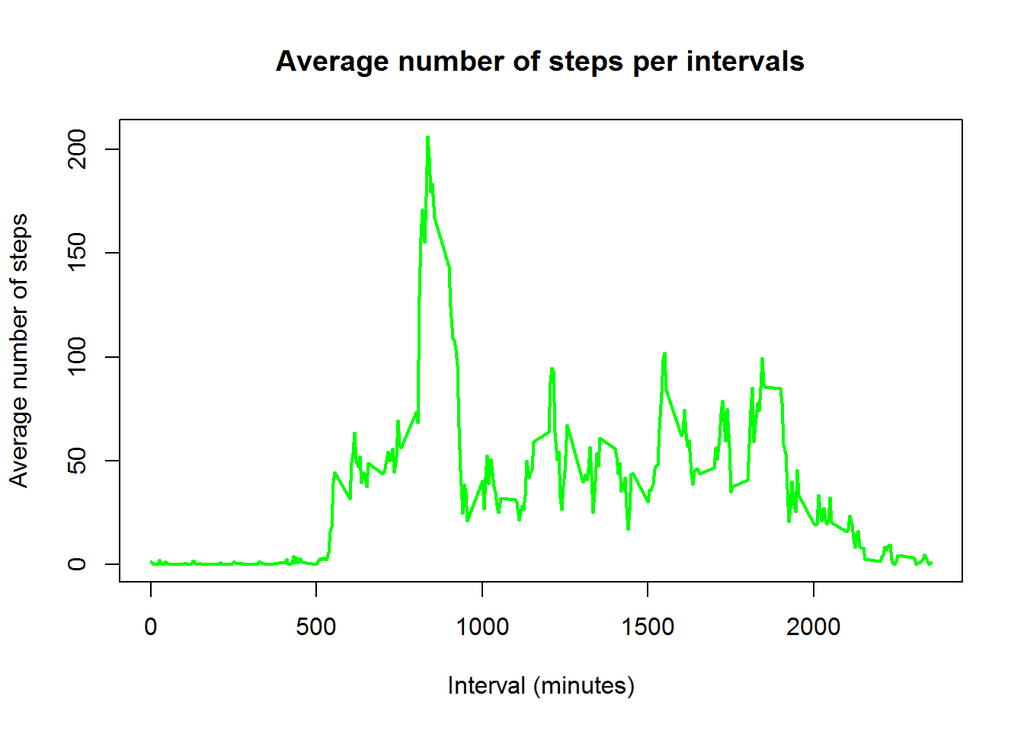

```r
activity_mean <- aggregate(activity$steps, by = list(activity$interval),
                           FUN = mean, na.rm = TRUE)

names(activity_mean) <- c("interval", "mean_steps")


plot(activity_mean$interval, activity_mean$mean_steps, type = "l", col = "green",
     lwd = 2, xlab = "Interval (minutes)", ylab = "Average number of steps",
     main = "Average number of steps per intervals")
```

2. The 5-minute interval which contains the maximum number of steps is 835. This can be seen using the code below:

```r
activity_mean[which(activity_mean$mean_steps ==max(activity_mean$mean_steps)),1]
```

```
## [1] 835
```

```r
max_step_int <- activity_mean[which.max(activity_mean$mean_steps),]
```

## Imputing missing values

1. Total number of missing values in the data set is 2304

```r
sum(is.na(activity$steps))
```

```
## [1] 2304
```

2. The missing values in the data are replaced by the mean for the 5 minute interval

```r
activity_with_NA <- activity[(is.na(activity$steps)),]
activity_without_NA <- activity[!(is.na(activity$steps)),]

#impute the average steps in place of missing values
activity_with_NA_imp <- sqldf("SELECT date, weekday, mean_steps, interval
                              FROM activity_with_NA
                              JOIN activity_mean USING(interval)")
names(activity_with_NA_imp)[names(activity_with_NA_imp) == "mean_steps"] <- "steps"
```

3. A new dataset is created

```r
activity_imputed <- rbind(activity_with_NA_imp,activity_without_NA)
```

4. The histogram is then created with the imputed data

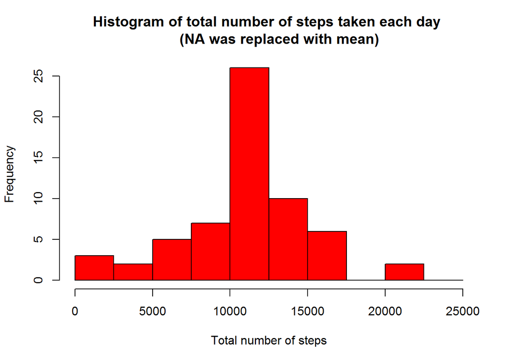

```r
daily_act_imputed <- aggregate(activity_imputed$steps,
                               by=list(activity_imputed$date), FUN = sum)
names(daily_act_imputed) <- c("date","Agg_activity")

hist(daily_act_imputed$Agg_activity, xlab = "Total number of steps",
     main = "Histogram of total number of steps taken each day
     (NA was replaced with mean)", col = "red",
     breaks = seq(from = 0, to = 25000, by = 2500))
```

Also, the mean and median of the imputed data is calculated.

With this estimated values imputed in the data and the mean and median are completely different

The mean is 10766, which is greater than the mean with missing values 9354 The median is 10766, which is also greater than the median with missing values 10395

```r
mean(daily_act_imputed$Agg_activity)
```

```
## [1] 10766.19
```

```r
median(daily_act_imputed$Agg_activity)
```

```
## [1] 10766.19
```

## Are there differences in activity patterns between weekdays and weekends?

1. We have created a new variable daytype which will determine whether or not the date is a weekday or not

```r
activity_imputed <- cbind(activity_imputed,
                          daytype = ifelse(activity_imputed$weekday
                                           == "Saturday" |
                          activity_imputed$weekday == "Sunday"
                          , "weekend", "weekday"))
```

2. A plot is then created containing the time series

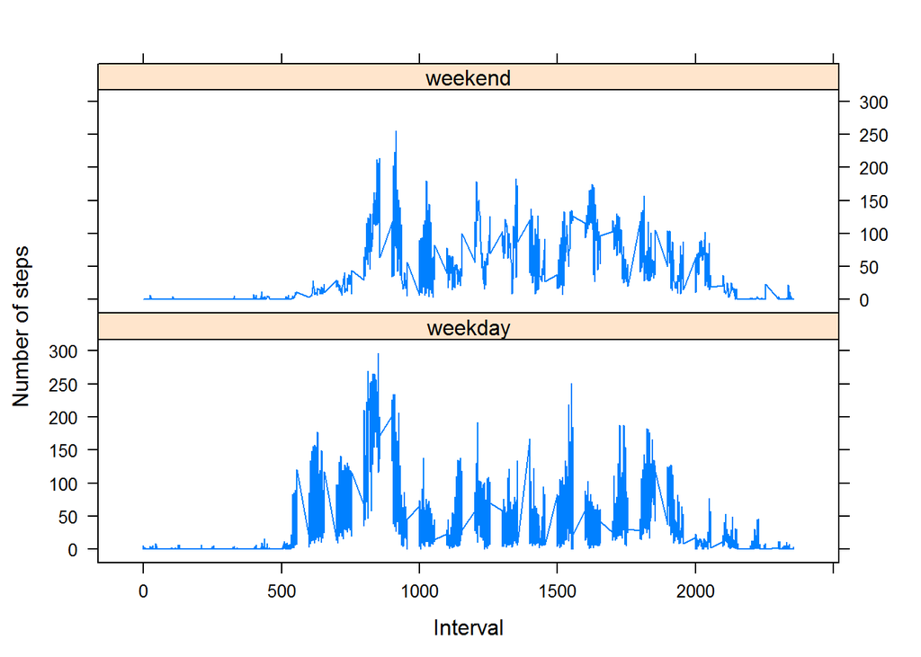

```r
library(lattice)
activity_mean <- aggregate(activity_imputed$steps,
                           by = list(activity_imputed$daytype,
                                     activity_imputed$weekday,
                                     activity_imputed$interval), mean)

names(activity_mean) <- c("daytype","weekday","interval", "mean_steps")

xyplot(mean_steps ~ interval | daytype,
       activity_mean, type = "l", lwd = 1,
       xlab = "Interval", ylab = "Number of steps",
       layout = c(1,2))
```